# plotting functional spaces

# 1. Set up

```r
library(tripack)
library(tidyverse)
library(here)

traits <- read_rds(here("data", "functional-traits", "trait_matrix.rds"))
comm_mat_algae <- read_rds(here("data", "SBC-LTE", "comm_mat_algae.rds"))
comm_meta <- read_rds(here("data", "SBC-LTE", "comm_meta.rds"))

low_col <- "#C70000"

medium_col <- "#54662C"

high_col <- "#114C54"
```

And just as a preview, this is what the trait matrix looks like:

```r
head(traits)
```

```
                                                        size_cm
Anisocladella pacifica                                        5
Acrosorium ciliolatum                                        20
Cryptopleura ruprechtiana                                    50
Bossiella orbigniana                                         21
Calliarthron cheilosporioides                                30
Chondracanthus corymbiferus; Chondracanthus exasperatus     100
                                                        position_to_benthos
Anisocladella pacifica                                              upright
Acrosorium ciliolatum                                               upright
Cryptopleura ruprechtiana                                           upright
Bossiella orbigniana                                    upright or crustose
Calliarthron cheilosporioides                           upright or crustose
Chondracanthus corymbiferus; Chondracanthus exasperatus             upright
                                                        stipe midrib
Anisocladella pacifica                                      y      y
Acrosorium ciliolatum                                       n      n
Cryptopleura ruprechtiana                                   n      n
Bossiella orbigniana                                        n      y
Calliarthron cheilosporioides                               n      n
Chondracanthus corymbiferus; Chondracanthus exasperatus     y      n
                                                          branching
Anisocladella pacifica                                    irregular
Acrosorium ciliolatum                                     irregular
Cryptopleura ruprechtiana                               dichotomous
Bossiella orbigniana                                    dichotomous
Calliarthron cheilosporioides                               pinnate
Chondracanthus corymbiferus; Chondracanthus exasperatus   irregular
                                                        branch_shape
Anisocladella pacifica                                     flattened
Acrosorium ciliolatum                                      flattened
Cryptopleura ruprechtiana                                  flattened
Bossiella orbigniana                                       flattened
Calliarthron cheilosporioides                              flattened
Chondracanthus corymbiferus; Chondracanthus exasperatus    flattened
                                                        blade_category
Anisocladella pacifica                                      many small
Acrosorium ciliolatum                                       many small
Cryptopleura ruprechtiana                                   many small
Bossiella orbigniana                                              none
```

[output cut: 8 more lines]

```
Chondracanthus corymbiferus; Chondracanthus exasperatus    discoid
                                                                        growth
Anisocladella pacifica                                                  apical
Acrosorium ciliolatum                                                   apical
Cryptopleura ruprechtiana                                               apical
Bossiella orbigniana                                                    apical
Calliarthron cheilosporioides                           intercalary or diffuse
Chondracanthus corymbiferus; Chondracanthus exasperatus                 apical
                                                        calcification
Anisocladella pacifica                                              n
Acrosorium ciliolatum                                               n
Cryptopleura ruprechtiana                                           n
Bossiella orbigniana                                                y
Calliarthron cheilosporioides                                       y
Chondracanthus corymbiferus; Chondracanthus exasperatus             n
```

And the structure:

```r
str(traits)
```

```
'data.frame':   42 obs. of  10 variables:
 $ size_cm            : num  5 20 50 21 30 100 18 10 20 41 ...
 $ position_to_benthos: Factor w/ 5 levels "upright","upright or crustose",..: 1 1 1 2 2 1 1 1 2 3 ...
 $ stipe              : Factor w/ 2 levels "y","n": 1 2 2 2 2 1 2 2 2 2 ...
 $ midrib             : Factor w/ 2 levels "y","n": 1 2 2 1 2 2 2 2 2 2 ...
 $ branching          : Factor w/ 5 levels "irregular","dichotomous",..: 1 1 2 2 3 1 1 2 3 2 ...
 $ branch_shape       : Factor w/ 4 levels "flattened","terete",..: 1 1 1 1 1 1 1 2 1 2 ...
 $ blade_category     : Factor w/ 4 levels "many small","none",..: 1 1 1 2 2 1 1 2 2 2 ...
 $ attachment         : Factor w/ 6 levels "stolon","rhizoidal",..: 1 2 3 4 4 3 3 2 4 3 ...
 $ growth             : Factor w/ 7 levels "apical","intercalary or diffuse",..: 1 1 1 1 2 1 1 2 1 3 ...
 $ calcification      : Factor w/ 2 levels "n","y": 1 1 1 2 2 1 1 1 2 1 ...
```

And this is the community matrix:

```r
head(comm_mat_algae)
```

```
                          Anisocladella pacifica Acrosorium ciliolatum
aque_continual_2010-04-26                 0.7625                     0
aque_continual_2010-07-22                 0.0000                     0
aque_continual_2010-10-13                 0.0000                     0
aque_control_2010-04-26                   0.0000                     0
aque_control_2010-07-22                   0.0000                     0
aque_control_2010-10-13                   0.0000                     0
                          Cryptopleura ruprechtiana Bossiella orbigniana
aque_continual_2010-04-26                      0.00                0.000
aque_continual_2010-07-22                      0.00                0.000
aque_continual_2010-10-13                      0.00                0.000
aque_control_2010-04-26                        0.00                2.525
aque_control_2010-07-22                        4.85                2.525
aque_control_2010-10-13                        4.85                0.000
                          Calliarthron cheilosporioides
aque_continual_2010-04-26                             0
aque_continual_2010-07-22                             0
aque_continual_2010-10-13                             0
aque_control_2010-04-26                               0
aque_control_2010-07-22                               0
aque_control_2010-10-13                               0
                          Chondracanthus corymbiferus; Chondracanthus exasperatus
aque_continual_2010-04-26                                                 0.00000
aque_continual_2010-07-22                                                 0.00000
aque_continual_2010-10-13                                                 2.11250
aque_control_2010-04-26                                                   7.39375
aque_control_2010-07-22                                                  13.73125
aque_control_2010-10-13                                                   9.50625
                          Callophyllis flabellulata Cladophora graminea
aque_continual_2010-04-26                    0.0000                   0
aque_continual_2010-07-22                    0.0000                   0
aque_continual_2010-10-13                    0.0000                   0
aque_control_2010-04-26                      0.4375                   0
aque_control_2010-07-22                      0.4375                   0
aque_control_2010-10-13                      0.4375                   0
                          Corallina officinalis Codium fragile
aque_continual_2010-04-26               1.33125              0
aque_continual_2010-07-22               0.00000              0
aque_continual_2010-10-13               0.00000              0
aque_control_2010-04-26                 2.66250              0
```

[output cut: 106 more lines]

```
aque_control_2010-10-13                   0         1.40625
                          Stenogramma californicum Taonia lennebackerae
aque_continual_2010-04-26                   0.0000                0.000
aque_continual_2010-07-22                   0.7625                1.350
aque_continual_2010-10-13                   0.7625                0.000
aque_control_2010-04-26                     0.0000                0.675
aque_control_2010-07-22                     0.0000                4.050
aque_control_2010-10-13                     0.7625                1.350
                          Ulva spp.
aque_continual_2010-04-26         0
aque_continual_2010-07-22         0
aque_continual_2010-10-13         0
aque_control_2010-04-26           0
aque_control_2010-07-22           0
aque_control_2010-10-13           0
```

And this is the metadata:

```r
head(comm_meta)
```

```
# A tibble: 6 × 19
  sample_ID   season_ID site  date        year month treatment exp_dates quarter
  <fct>       <fct>     <fct> <date>     <dbl> <dbl> <fct>     <fct>     <fct>
1 aque_conti… 2010_spr… aque  2010-04-26  2010     4 continual during    Q2
2 aque_conti… 2010_sum… aque  2010-07-22  2010     7 continual during    Q3
3 aque_conti… 2010_fal… aque  2010-10-13  2010    10 continual during    Q4
4 aque_contr… 2010_spr… aque  2010-04-26  2010     4 control   during    Q2
5 aque_contr… 2010_sum… aque  2010-07-22  2010     7 control   during    Q3
6 aque_contr… 2010_fal… aque  2010-10-13  2010    10 control   during    Q4
# ℹ 10 more variables: time_yrs <dbl>, time_since_start <dbl>,
#   time_since_end <dbl>, kelp_year <fct>, comp_1yrs <fct>, comp_2yrs <fct>,
#   comp_3yrs <fct>, quality <fct>, site_full <fct>, season <fct>
```

# 2. Generate PCoA axes

Then, I generate the Gower dissimilarity matrix and do a PCoA to get the “synthetic” traits.

```r
# generate Gower matrix
trait_gower <- FD::gowdis(traits)

# doing PCoA to get dimensions
trait_pcoa <- ape::pcoa(D = trait_gower)

# extracting axis values as data frame
spp_pcoa_scores <- trait_pcoa$vectors %>%
  as_tibble(rownames = NA) %>%
  rownames_to_column("scientific_name")
```

# 3. Getting the “global pool”

So this is where I get the whole trait space for all the species in the study.

```r
# get the PCoA axes for axis
m <- trait_pcoa$vectors

# get the set of triangles that defines the hull
tr <- tri.mesh(m[,1], m[,2])

# get the points on the outside of the hull
# ch stands for "convex hull"
ch <- convex.hull(tr) %>%
  data.frame() %>%
  rownames_to_column("scientific_name")
```

And then just to see what the `ch` object looks like:

```r
ch
```

```
                scientific_name          x            y  i
1          Bossiella orbigniana  0.2978501 -0.388593342  4
2 Calliarthron cheilosporioides  0.4293887 -0.143323442  5
3        Lithothrix aspergillum  0.3793014 -0.005862679 26
4          Colpomenia peregrina  0.2189053  0.248592196 11
5            Laminaria farlowii -0.1285632  0.450115642 25
6             Egregia menziesii -0.4570812 -0.160829379 18
7       Nienburgia andersoniana -0.1526986 -0.270659045 29
```

```r
str(ch)
```

```
'data.frame':   7 obs. of  4 variables:
 $ scientific_name: chr  "Bossiella orbigniana" "Calliarthron cheilosporioides" "Lithothrix aspergillum" "Colpomenia peregrina" ...
 $ x              : num  0.298 0.429 0.379 0.219 -0.129 ...
 $ y              : num  -0.38859 -0.14332 -0.00586 0.24859 0.45012 ...
 $ i              : int  4 5 26 11 25 18 29
```

# 4. Survey trait space

So, I have a lot of surveys. I did this all in a nested data frame structure (instead of a for() loop) because I needed to do the same thing a bunch of times for different subsets of the data.

At the end of this chunk, I’ll have the convex hull for every survey (with more than 2 species, because you can’t draw a convex hull with only two points, as I learned!).

```r
species_presence <- comm_mat_algae %>%
  # turn the matrix into a data frame
  as_tibble(rownames = "sample_ID") %>%

  # filter out species that don't appear in that survey
  # if the species biomass is greater than 0, replace that number with "yes"
  # if not, then "no"
  mutate(across(where(is.numeric),
                ~ case_when(. > 0 ~ "yes", TRUE ~ "no"))) %>%

  # make the data frame longer
  pivot_longer(cols = 2:43,
               names_to = "scientific_name",
               values_to = "presence") %>%

  # join with PCoA scroes from above
  left_join(., spp_pcoa_scores, by = "scientific_name") %>%

  # nest the data frame by sample_ID (representing each survey)
  nest(.by = sample_ID, data = everything()) %>%

  # NOTE: this is the start of the nested structure
  # filter the data frame to only include the species that occur in that survey
  mutate(filtered_comm = map2(
    data, sample_ID,
    ~ filter(.x, sample_ID == .y & presence == "yes")
  )) %>%

  # create a matrix with the species name, PCoA 1 axis, and PCoA 2 axis
  mutate(coords = map(
    filtered_comm,
    ~ select(.x,
             scientific_name, Axis.1, Axis.2) %>%
      column_to_rownames("scientific_name") %>%
      as.matrix()
  )) %>%

  # count the number of species in that survey
  mutate(hull_outside_species = map(
    filtered_comm,
    ~ nrow(.x)
  )) %>%

  # filter to only include surveys with more than 2 species
  filter(hull_outside_species > 2) %>%
  mutate(trimesh = map(
    coords,
    ~ tri.mesh(.x[, 1], .x[, 2])
  )) %>%

  # calculate the convex hull
  mutate(convex_hull = map(
    trimesh,
    ~ convex.hull(.x) %>%
      data.frame() %>%
      rownames_to_column("scientific_name")
  )) %>%

  # join metadata information
  left_join(., comm_meta, by = "sample_ID")
```

# 5. wrangling

Whew! ok. So now I pull out the hulls for each survey and unnest the data frame.

The output then looks like a regular data frame, but now with the species representing the outer edges of the convex hull (`scientific_name`) and the axis positions (`x` and `y`).

```r
hulls <- species_presence %>%
  select(sample_ID, convex_hull) %>%
  unnest(cols = c(convex_hull)) %>%
  left_join(., comm_meta, by = "sample_ID")

head(hulls)
```

```
# A tibble: 6 × 23
  sample_ID      scientific_name      x       y     i season_ID site  date
  <chr>          <chr>            <dbl>   <dbl> <int> <fct>     <fct> <date>
1 aque_continua… Anisocladella … -0.293 -0.152      1 2010_spr… aque  2010-04-26
2 aque_continua… Nienburgia and… -0.153 -0.271      7 2010_spr… aque  2010-04-26
3 aque_continua… Corallina offi…  0.349 -0.196      2 2010_spr… aque  2010-04-26
4 aque_continua… Pterygophora c… -0.148  0.336      9 2010_spr… aque  2010-04-26
5 aque_continua… Stephanocystis… -0.295  0.0435     3 2010_spr… aque  2010-04-26
6 aque_continua… Stephanocystis… -0.295  0.0435     1 2010_sum… aque  2010-07-22
# ℹ 15 more variables: year <dbl>, month <dbl>, treatment <fct>,
#   exp_dates <fct>, quarter <fct>, time_yrs <dbl>, time_since_start <dbl>,
#   time_since_end <dbl>, kelp_year <fct>, comp_1yrs <fct>, comp_2yrs <fct>,
#   comp_3yrs <fct>, quality <fct>, site_full <fct>, season <fct>
```

# 6. plotting

And then plot!

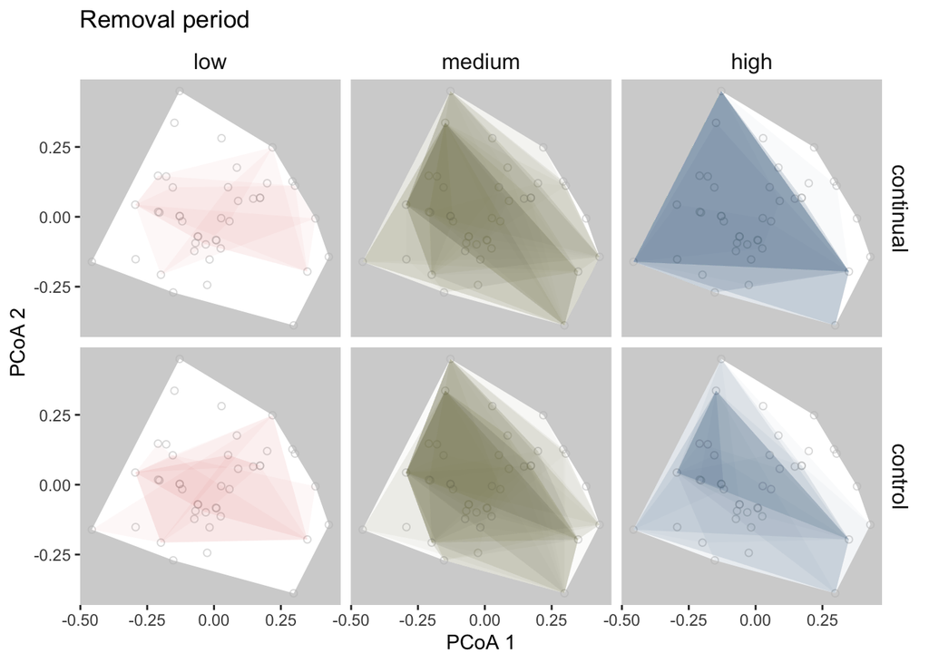

```r
during_space <- ggplot() +
  theme(panel.background = element_rect(fill = "lightgrey")) +

  # global species pool
  geom_polygon(data = ch,
               aes(x = x,
                   y = y),
               fill = "#FFFFFF") +
  geom_point(data = m,
             aes(x = Axis.1,
                 y = Axis.2),
             color = "grey",
             shape = 21,
             alpha = 0.5) +

  # survey hulls
  geom_polygon(data = hulls %>%
                 filter(exp_dates == "during" & quality == "high"),
               aes(x = x,
                   y = y,
                   group = sample_ID),
               alpha = 0.025,
               fill = high_col
  ) +
  geom_polygon(data = hulls %>%
                 filter(exp_dates == "during" & quality == "medium"),
               aes(x = x,
                   y = y,
                   group = sample_ID),
               alpha = 0.025,
               fill = medium_col
  ) +
  geom_polygon(data = hulls %>%
                 filter(exp_dates == "during" & quality == "low"),
               aes(x = x,
                   y = y,
                   group = sample_ID),
               alpha = 0.03,
               fill = low_col
  ) +
  facet_grid(cols = vars(quality), vars(treatment)) +
  labs(title = "Removal period",
       x = "PCoA 1",
       y = "PCoA 2") +
  theme(strip.background = element_blank(),
        strip.text = element_text(size = 12),
        panel.grid = element_blank())

after_space <- ggplot() +
  theme(panel.background = element_rect(fill = "lightgrey")) +
  # global species pool
  geom_polygon(data = ch,
               aes(x = x,
                   y = y),
               fill = "#FFFFFF") +
  geom_point(data = m,
             aes(x = Axis.1,
                 y = Axis.2),
             color = "grey",
             shape = 21,
             alpha = 0.5) +
  geom_polygon(data = hulls %>%
                 filter(exp_dates == "after" & quality == "high"),
               aes(x = x,
                   y = y,
                   group = sample_ID),
               alpha = 0.025,
               fill = high_col
  ) +
  geom_polygon(data = hulls %>%
                 filter(exp_dates == "after" & quality == "medium"),
               aes(x = x,
                   y = y,
                   group = sample_ID),
               alpha = 0.025,
               fill = medium_col
  ) +
  geom_polygon(data = hulls %>%
                 filter(exp_dates == "after" & quality == "low"),
               aes(x = x,
                   y = y,
                   group = sample_ID),
               alpha = 0.03,
               fill = low_col
  ) +
  facet_grid(cols = vars(quality), vars(treatment)) +
  labs(title = "Recovery period",
       x = "PCoA 1",
       y = "PCoA 2") +
  theme(strip.background = element_blank(),
        strip.text = element_text(size = 12),
        panel.grid = element_blank())

during_space
```

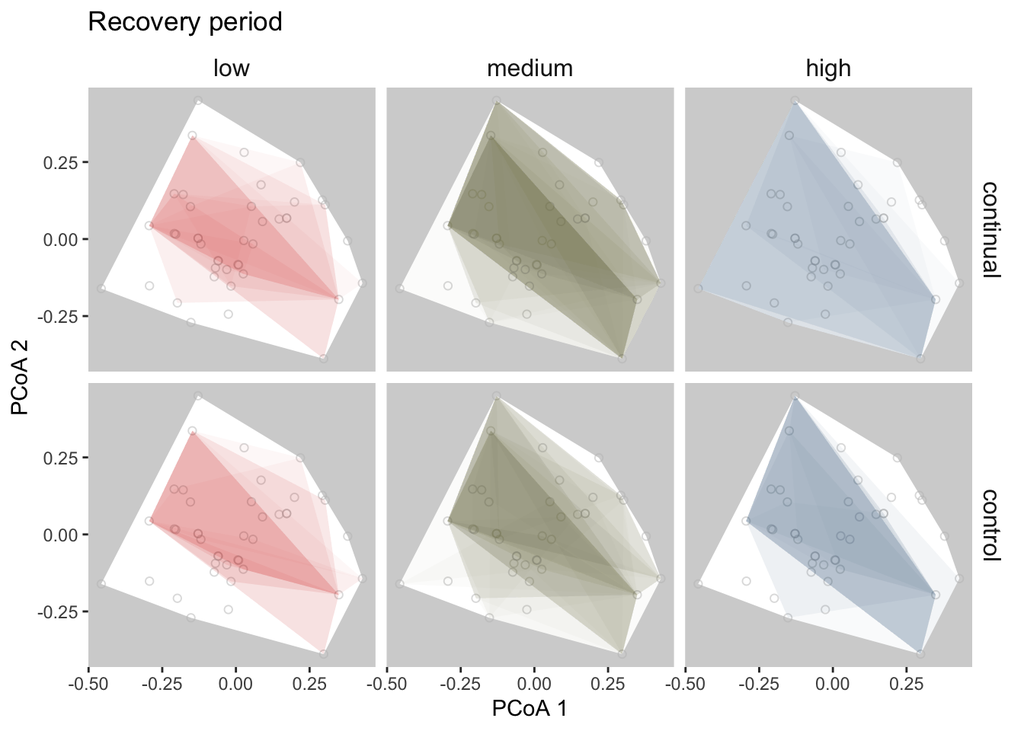

```r
after_space
```